# Barbell Activities

J.C. French

October 23, 2015

## Summary

The goal of the Practical Machine Learning class assignment is to build a machine learning prediction model which accurately classifies what “classe” of activity is being performed based on data from activity monitors strapped to test subjects while they perform one of five different exercise activities.

The original Human Activity Recognition (HAR) study and data is documented at this website: http://groupware.les.inf.puc-rio.br/har

52 features were selected from the training data. 10% of the training data was set aside to estimate an out of sample rate. A random forest machine learning model was developed from the remaining training data.

## Source Data & Initial Load:

The project data sets were collected from the following links:

- pml-training link: https://d396qusza40orc.cloudfront.net/predmachlearn/pml-training.csv
- pml-testing link: https://d396qusza40orc.cloudfront.net/predmachlearn/pml-testing.csv

*Note, from this point on, the data from the pml-testing link will be referred to as validation data.

Each file was read using a csv parser (read.csv). “NA” strings and blank entries were converted to NA values.

### Data Exploration & Feature Selection

The assignment requested a model to predict the “classe” outcome based on other features provided in the dataset. Of these remaining 159 features, 100 features are derived features which are only provided on records which summarize each “observational window”. Since these calculated values were not provided in the validation test set, these 100 features were removed from consideration.

Next, the remaining 59 features were reviewed to identify “near zero variance” features. This identified the “new_window” feature. The new_window line contains calculated summary data across an observational window. Careful manual review of the first few features revealed that the first 7 variables should be eliminated, as the information in these variables is not activity monitor metrics: “X”, “user_name”, “raw_timestamp_part_1”, “raw_timestamp_part_2”, “cvtd_timestamp”, “new_window”, “num_window”.

The remaining training data set contained 52 features and one outcome, “classe”.

```r
str(rawtraining,list.len=15)
```

```
## 'data.frame':    19622 obs. of  160 variables:
##  $ X                       : int  1 2 3 4 5 6 7 8 9 10 ...
##  $ user_name               : Factor w/ 6 levels "adelmo","carlitos",..: 2 2 2 2 2 2 2 2 2 2 ...
##  $ raw_timestamp_part_1    : int  1323084231 1323084231 1323084231 1323084232 1323084232 1323084232 1323084232 1323084232 1323084232 1323084232 ...
##  $ raw_timestamp_part_2    : int  788290 808298 820366 120339 196328 304277 368296 440390 484323 484434 ...
##  $ cvtd_timestamp          : Factor w/ 20 levels "02/12/2011 13:32",..: 9 9 9 9 9 9 9 9 9 9 ...
##  $ new_window              : Factor w/ 2 levels "no","yes": 1 1 1 1 1 1 1 1 1 1 ...
##  $ num_window              : int  11 11 11 12 12 12 12 12 12 12 ...
##  $ roll_belt               : num  1.41 1.41 1.42 1.48 1.48 1.45 1.42 1.42 1.43 1.45 ...
##  $ pitch_belt              : num  8.07 8.07 8.07 8.05 8.07 8.06 8.09 8.13 8.16 8.17 ...
##  $ yaw_belt                : num  -94.4 -94.4 -94.4 -94.4 -94.4 -94.4 -94.4 -94.4 -94.4 -94.4 ...
##  $ total_accel_belt        : int  3 3 3 3 3 3 3 3 3 3 ...
##  $ kurtosis_roll_belt      : Factor w/ 396 levels "-0.016850","-0.021024",..: NA NA NA NA NA NA NA NA NA NA ...
##  $ kurtosis_picth_belt     : Factor w/ 316 levels "-0.021887","-0.060755",..: NA NA NA NA NA NA NA NA NA NA ...
##  $ kurtosis_yaw_belt       : Factor w/ 1 level "#DIV/0!": NA NA NA NA NA NA NA NA NA NA ...
##  $ skewness_roll_belt      : Factor w/ 394 levels "-0.003095","-0.010002",..: NA NA NA NA NA NA NA NA NA NA ...
##   [list output truncated]
```

```r
table(rawtraining$classe)
```

```
##
##    A    B    C    D    E
## 5580 3797 3422 3216 3607
```

### Exploratory Plot

Next, the “caret” package’s featurePlot function was used to graphically explore the training data. While some data trends show up, interpreting these clusters was not feasible within the limited scope of this analysis. The following pairwise graph presents many clusters, but most cluster do not provide visually distinguishable groupings.

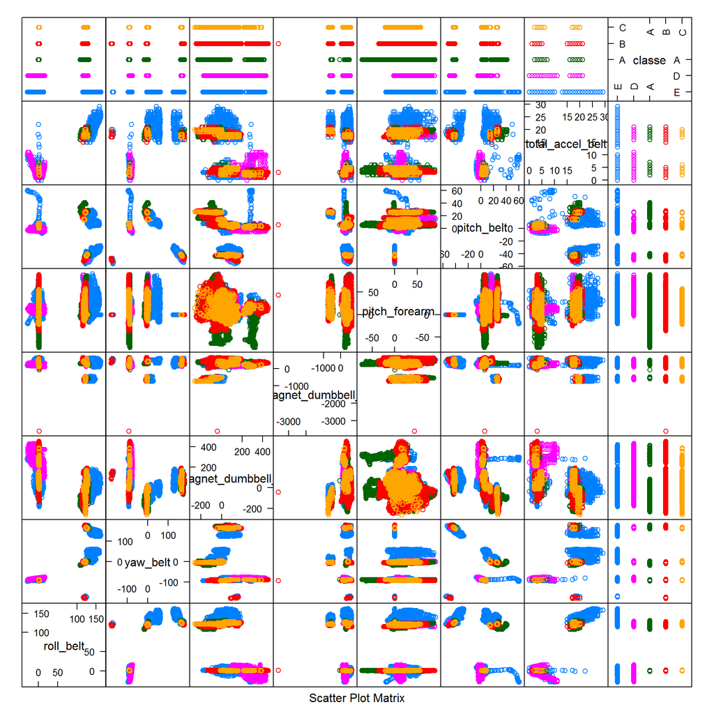

### Training a Random Forest Model

```r
fit <-train(classe ~ ., data=training,
            model="rf",
            trControl=trainControl(allowParallel=T,
                                   method="cv",
                                   number=4)
            )
fit
```

```
## Random Forest
##
## 17662 samples
##    52 predictor
##     5 classes: 'A', 'B', 'C', 'D', 'E'
##
## No pre-processing
## Resampling: Cross-Validated (4 fold)
## Summary of sample sizes: 13247, 13245, 13247, 13247
## Resampling results across tuning parameters:
##
##   mtry  Accuracy   Kappa      Accuracy SD  Kappa SD
##    2    0.9933753  0.9916197  0.002873772  0.003635441
##   27    0.9930356  0.9911901  0.002428721  0.003072709
##   52    0.9877134  0.9844572  0.002450823  0.003101849
##
## Accuracy was used to select the optimal model using  the largest value.
## The final value used for the model was mtry = 2.
```

```r
fit$finalModel
```

```
##
## Call:
##  randomForest(x = x, y = y, mtry = param$mtry, model = "rf")
##                Type of random forest: classification
##                      Number of trees: 500
## No. of variables tried at each split: 2
##
##         OOB estimate of  error rate: 0.49%
## Confusion matrix:
##      A    B    C    D    E  class.error
## A 5019    2    1    0    0 0.0005973716
## B   13 3403    2    0    0 0.0043885313
## C    0   19 3058    3    0 0.0071428571
## D    0    0   41 2853    1 0.0145077720
## E    0    0    0    5 3242 0.0015398830
```

### Varaible Importance

The caret “varImp” function provides insight into which features have the greatest impact in our random forest model.

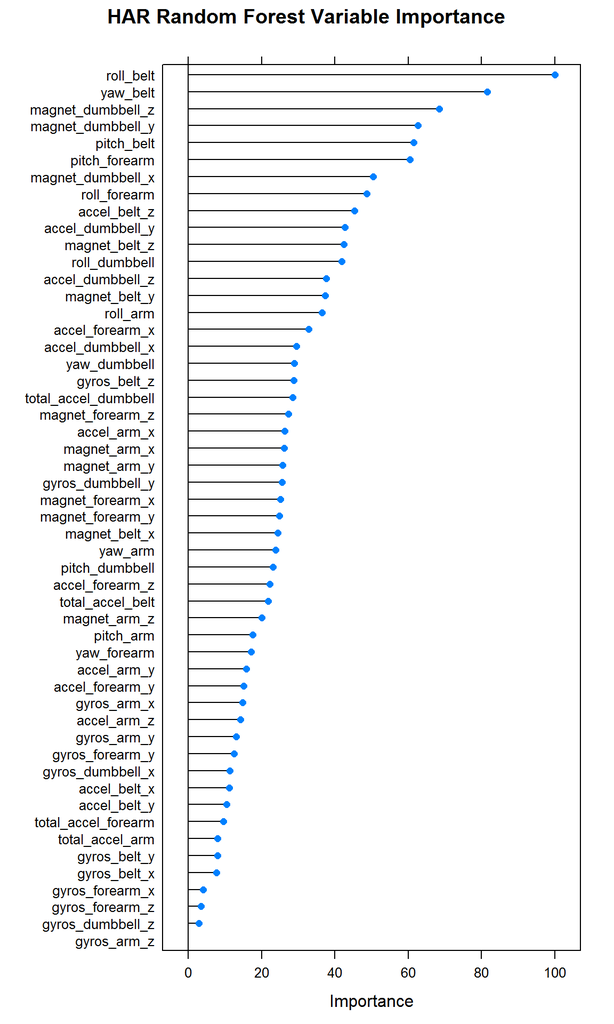

### Testing vs. Cross Validation

```r
prediction <- predict(fit, newdata=testing)
confusionMatrix(testing$classe,prediction)
```

```
## Confusion Matrix and Statistics
##
##           Reference
## Prediction   A   B   C   D   E
##          A 558   0   0   0   0
##          B   3 375   1   0   0
##          C   0   2 339   1   0
##          D   0   0   4 316   1
##          E   0   0   0   0 360
##
## Overall Statistics
##
##                Accuracy : 0.9939
##                  95% CI : (0.9893, 0.9968)
##     No Information Rate : 0.2862
##     P-Value [Acc > NIR] : < 2.2e-16
##
##                   Kappa : 0.9923
##  Mcnemar's Test P-Value : NA
##
## Statistics by Class:
##
##                      Class: A Class: B Class: C Class: D Class: E
## Sensitivity            0.9947   0.9947   0.9855   0.9968   0.9972
## Specificity            1.0000   0.9975   0.9981   0.9970   1.0000
## Pos Pred Value         1.0000   0.9894   0.9912   0.9844   1.0000
## Neg Pred Value         0.9979   0.9987   0.9969   0.9994   0.9994
## Prevalence             0.2862   0.1923   0.1755   0.1617   0.1842
## Detection Rate         0.2847   0.1913   0.1730   0.1612   0.1837
## Detection Prevalence   0.2847   0.1934   0.1745   0.1638   0.1837
## Balanced Accuracy      0.9973   0.9961   0.9918   0.9969   0.9986
```

### Validation

The “classe” value was predicted classes for the validation observation with the random forest model.

### Results

Using the code snippet provided by Proffesor Leek, the predicted 20 valdiation values were converted into a character array and used to generate 20 validation files. These files were submitted without any errors.